# 3.3 Markdown

2022-06-15

# Load Dataset and required packages

- skip first column (column number)

```r
rm(list = ls()) # clears everything
# install.packages("tree")
library(tree)

carseats <- read.csv(file = 'carseats.csv', colClasses = (c("NULL", replicate(11, NA))))

# View(carseats)
```

# Exercise 1

Split the variables sales into a binary outcome variable with High = 1 if Sales > 8 and 0 otherwise.

```r
carseats$HighSales <- as.factor(ifelse(carseats$Sales <= 8, "Low", "High"))

table(carseats$Sales, carseats$HighSales)
```

[output not shown]

[output cut: 283 more lines]

[output not shown]

# Exercise 2

Estimate an unpruned classification regression tree for the High/Low sales variable with minimum size node of 12. - make character variables factor before

```r
carseats$Urban <- as.factor(carseats$Urban)
carseats$ShelveLoc <- factor(carseats$ShelveLoc)
carseats$US <- as.factor(carseats$US)

seat_tree = tree(HighSales ~ . - Sales, data = carseats, minsize = 12)
```

# Exercise 3

Plot the unpruned classification regression tree.

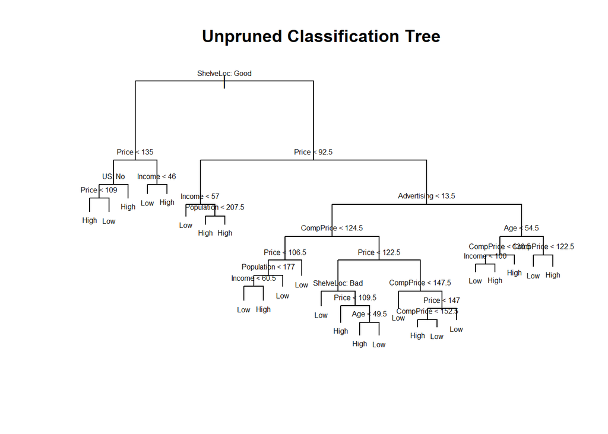

```r
plot(seat_tree)
text(seat_tree, pretty = 0, cex = 0.5)
title(main = "Unpruned Classification Tree")
```

# Exercise 4

Report for the unpruned classification regression tree the number of terminal nodes, the residual deviance and the misclassification error rate.

```r
summary(seat_tree)
```

```
##
## Classification tree:
## tree(formula = HighSales ~ . - Sales, data = carseats, minsize = 12)
## Variables actually used in tree construction:
## [1] "ShelveLoc"   "Price"       "US"          "Income"      "Population"
## [6] "Advertising" "CompPrice"   "Age"
## Number of terminal nodes:  25
## Residual mean deviance:  0.5067 = 190 / 375
## Misclassification error rate: 0.105 = 42 / 400
```

# Exercise 5

Split the total sample randomly into a training data set and a test data set with 200 obser- vations each

```r
dim(carseats)
```

```
## [1] 400  12
```

```r
set.seed(2)
seat_idx = sample(1:nrow(carseats), 200)
seat_trn = carseats[seat_idx,]
seat_tst = carseats[-seat_idx,]
```

# Exercise 6

Compute an unpruned tree with minimum node size 12 for the training data.

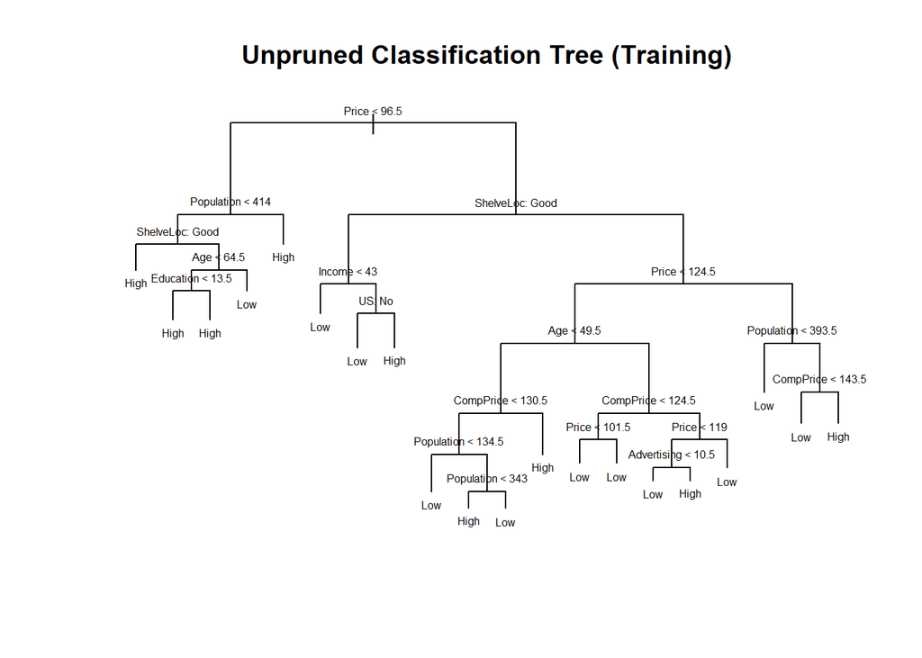

```r
seat_tree_trn = tree(HighSales ~ . - Sales, data = seat_trn, minsize = 12)
plot(seat_tree_trn)
text(seat_tree_trn, pretty = 0, cex = 0.5)
title(main = "Unpruned Classification Tree (Training)")
```

```r
summary(seat_tree_trn)
```

```
##
## Classification tree:
## tree(formula = HighSales ~ . - Sales, data = seat_trn, minsize = 12)
## Variables actually used in tree construction:
## [1] "Price"       "Population"  "ShelveLoc"   "Age"         "Education"
## [6] "Income"      "US"          "CompPrice"   "Advertising"
## Number of terminal nodes:  20
## Residual mean deviance:  0.5727 = 103.1 / 180
## Misclassification error rate: 0.13 = 26 / 200
```

# Exercise 7

Predict the tree for the training data and for the test data and compare the major summary statistics

```r
seat_trn_pred = predict(seat_tree_trn, seat_trn, type = "class")
seat_tst_pred = predict(seat_tree_trn, seat_tst, type = "class")
```

# Exercise 8

Report the confusion matrices for the test and the training data and the corresponding accu- racy measures

```r
# train confusion
table(predicted = seat_trn_pred, actual = seat_trn$HighSales)
```

```
##          actual
## predicted High Low
##      High   63   8
##      Low    18 111
```

```r
# test confusion
table(predicted = seat_tst_pred, actual = seat_tst$HighSales)
```

```
##          actual
## predicted High Low
##      High   50  12
##      Low    33 105
```

```r
accuracy = function(actual, predicted) {
  mean(actual == predicted)
}

# train acc
accuracy(predicted = seat_trn_pred, actual = seat_trn$HighSales)
```

```
## [1] 0.87
```

```r
#test acc
accuracy(predicted = seat_tst_pred, actual = seat_tst$HighSales)
```

```
## [1] 0.775
```

# Exercise 9

Use a ten-fold cross-validation on the tree of the test set with number of terminal nodes equal to 9 and 14.

```r
# When setting a seed in a codebox in markdown, it does so only for given codebox,
# such that we have to set a seed again for reporducibility
set.seed(420)

# cross validation using classification error rate as indicator
seat_tree_cv <- cv.tree(seat_tree_trn, FUN = prune.misclass)
# cross validation results: size -> terminal nodes, dev -> missclassifications, k -> cost complexity parameter
seat_tree_cv$size
```

```
## [1] 20 17 12  9  8  5  3  2  1
```

```r
seat_tree_cv$dev
```

```
## [1] 65 64 72 72 75 79 76 77 84
```

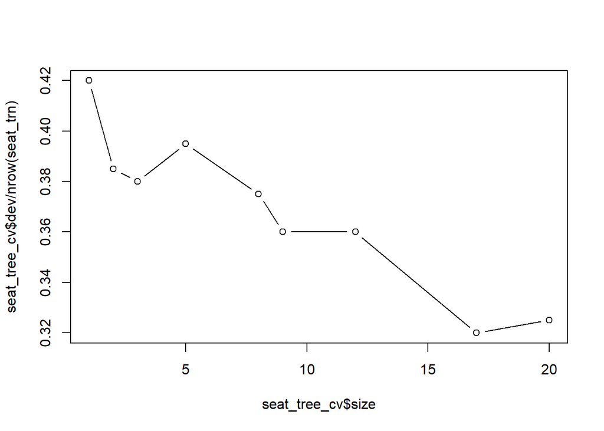

```r
# plot the error rate
plot(seat_tree_cv$size, seat_tree_cv$dev/nrow(seat_trn), type = "b")
```

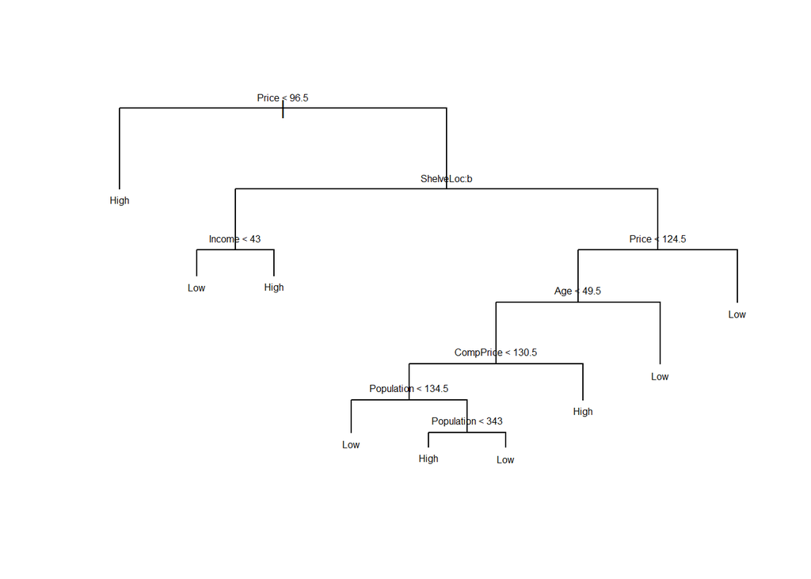

```r
# 9 nodes
seat_tree_trn_cv_9 = cv.tree(seat_tree_trn, FUN = prune.misclass, best = 9)
plot(seat_tree_trn_cv_9)
text(seat_tree_trn_cv_9, cex = 0.5)
```

```r
seat_trn_cv_9_pred <- predict(seat_tree_trn_cv_9, seat_trn, type = "class")
seat_tst_cv_9_pred <- predict(seat_tree_trn_cv_9, seat_tst, type = "class")

# train acc
accuracy(predicted = seat_trn_cv_9_pred, actual = seat_trn$HighSales)
```

```
## [1] 0.825
```

```r
#test acc
accuracy(predicted = seat_tst_cv_9_pred, actual = seat_tst$HighSales)
```

```
## [1] 0.775
```

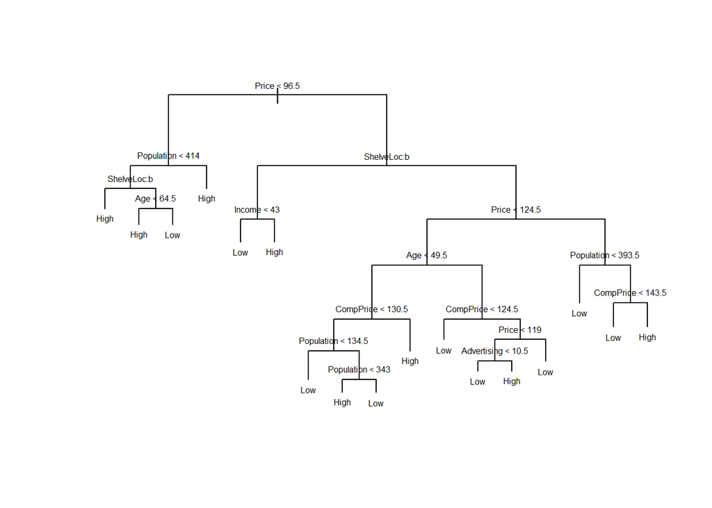

```r
# it is not possible to generate a tree with 14 nodes because of the minsize requirement we used prior
# a tree with 14 terminal nodes is not considered (like in the original example)
# the prune.missclass function defaults to using the next higher treesize (which is 17)
# 14 nodes
seat_tree_trn_cv_14 = cv.tree(seat_tree_trn, FUN = prune.misclass, best = 14)
plot(seat_tree_trn_cv_14)
text(seat_tree_trn_cv_14, cex = 0.5)
```

```r
seat_trn_cv_14_pred <- predict(seat_tree_trn_cv_14, seat_trn, type = "class")
seat_tst_cv_14_pred <- predict(seat_tree_trn_cv_14, seat_tst, type = "class")

# train acc
accuracy(predicted = seat_trn_cv_14_pred, actual = seat_trn$HighSales)
```

```
## [1] 0.87
```

```r
#test acc
accuracy(predicted = seat_tst_cv_14_pred, actual = seat_tst$HighSales)
```

```
## [1] 0.795
```

From Cross validation we know that the tree size of 12 seems to be as good as 9, let’s try for fun

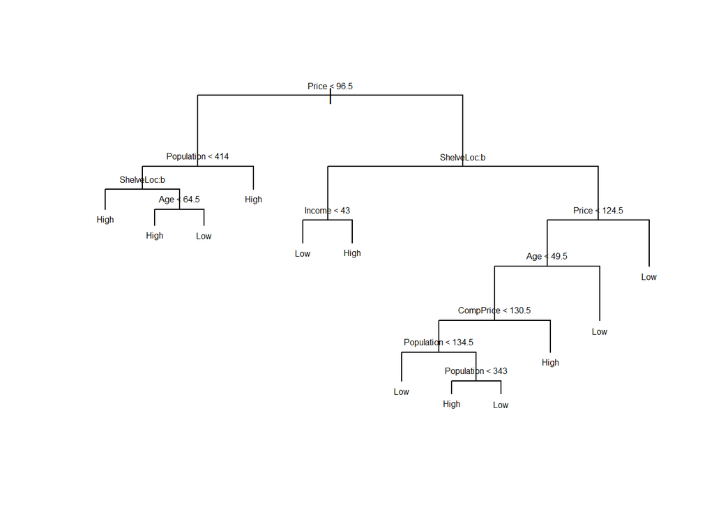

```r
# 12 nodes
seat_tree_trn_cv_12 = prune.misclass(seat_tree_trn, best = 12)
plot(seat_tree_trn_cv_12)
text(seat_tree_trn_cv_12, cex = 0.5)
```

```r
seat_tree_trn_cv_12_pred <- predict(seat_tree_trn_cv_12, seat_trn, type = "class")
seat_tree_tst_cv_12_pred <- predict(seat_tree_trn_cv_12, seat_tst, type = "class")

table(predicted = seat_tree_trn_cv_12_pred, actual = seat_trn$HighSales)
```

```
##          actual
## predicted High Low
##      High   60  10
##      Low    21 109
```

```r
accuracy(actual = seat_trn$HighSales, predicted = seat_tree_trn_cv_12_pred)
```

```
## [1] 0.845
```

```r
table(predicted = seat_tree_tst_cv_12_pred, actual = seat_tst$HighSales)
```

```
##          actual
## predicted High Low
##      High   56  15
##      Low    27 102
```

```r
accuracy(actual = seat_tst$HighSales, predicted = seat_tree_tst_cv_12_pred)
```

```
## [1] 0.79
```